# Содержание:

# Выявить закономерности определяющие успешность игры

Нам нужно по историческим данным о продаже игр сделать анализ и выявить закономерности определяющие успешность игры для выявление потенциально популярного продукта и планирования рекламной компании.

**Цель исследования** — Выявить закономерности определяющие успешность игры

**Входные данный**

- `games.csv` - историческая база данных до 2016 г.

**Ход исследования**

1. **Обзор данных.** Мы проведем загрузку и обзор предоставленных данных.
2. **Предобработка данных.**
   - Проверим данные на ошибки и пропуски, поищем возможность исправить самые критические ошибки. Оценив их влияние на исследования.
   - Посчитаем суммарные продажи во всех регионах
3. **Проанализируем данные.**
   - Сколько игр выпускалось в разные годы
   - Посмотрим как менялись продажи по платформам.
   - Выберем платформы с наибольшими суммарными продажами и построем распределение по годам.
   - Посмотрим какие платформы лидируют по продажам.
   - Посмотрим на общее распределение игр по жанрам.
4. **Составим портрет пользователя каждого региона (NA, EU, JP)**
   - Самые популярные платформы (топ-5).
   - Самые популярные жанры (топ-5).
5. **Проверим гипотезы**
   - Средние пользовательские рейтинги платформ Xbox One и PC одинаковые;
   - Средние пользовательские рейтинги жанров Action и Sports разные.
6. **Вывод** Напишем общий вывод.

## Обзор данных

### Импорт библиотек и загрузка данных

`pandas` - для загрузки и обработки данных мы воспльзуемся библеотекой .

`matplotlib` - для работы с минимальным и максимальным желаемые значения для графиков.

`numpy` - библиотека высокоуровневых математических функций

`scipy` - библиотека математического и числового анализов

```python
import pandas as pd
import matplotlib.pyplot as plt
from scipy import stats as st
import numpy as np
import seaborn as sns
```

### Загрузим файлы из папки /datasets и сохраним в переменные

Выведем первые 5 строк таблицы и общую информацию:

```python
try:
    df = pd.read_csv('/datasets/games.csv')
    display('Загрузка онлайн')
except FileNotFoundError:
    df = pd.read_csv('D:/YandexDiskNew/Work/Analitic/Practicum/01_Module/5 - Сборный проект-1/games.csv')
    display('Загрузка офлайн')

df.info()
df.head(5)
```

```
'Загрузка офлайн'
```

```
<class 'pandas.core.frame.DataFrame'>
RangeIndex: 16715 entries, 0 to 16714
Data columns (total 11 columns):
 #   Column           Non-Null Count  Dtype
---  ------           --------------  -----
 0   Name             16713 non-null  object
 1   Platform         16715 non-null  object
 2   Year_of_Release  16446 non-null  float64
 3   Genre            16713 non-null  object
 4   NA_sales         16715 non-null  float64
 5   EU_sales         16715 non-null  float64
 6   JP_sales         16715 non-null  float64
 7   Other_sales      16715 non-null  float64
 8   Critic_Score     8137 non-null   float64
 9   User_Score       10014 non-null  object
 10  Rating           9949 non-null   object
dtypes: float64(6), object(5)
memory usage: 1.4+ MB
```

|  | Name | Platform | Year_of_Release | Genre | NA_sales | EU_sales | JP_sales | Other_sales | Critic_Score | User_Score | Rating |
| --- | --- | --- | --- | --- | --- | --- | --- | --- | --- | --- | --- |
| 0 | Wii Sports | Wii | 2006.0 | Sports | 41.36 | 28.96 | 3.77 | 8.45 | 76.0 | 8 | E |
| 1 | Super Mario Bros. | NES | 1985.0 | Platform | 29.08 | 3.58 | 6.81 | 0.77 | NaN | NaN | NaN |
| 2 | Mario Kart Wii | Wii | 2008.0 | Racing | 15.68 | 12.76 | 3.79 | 3.29 | 82.0 | 8.3 | E |
| 3 | Wii Sports Resort | Wii | 2009.0 | Sports | 15.61 | 10.93 | 3.28 | 2.95 | 80.0 | 8 | E |
| 4 | Pokemon Red/Pokemon Blue | GB | 1996.0 | Role-Playing | 11.27 | 8.89 | 10.22 | 1.00 | NaN | NaN | NaN |

## Предобработка данных

В названиях колонок присутствует нарушения стиля, приведем все к нижнему регистру.

```python
for i in range(len(df.columns)):
    df.columns = df.columns.str.lower()

df.columns
```

```
Index(['name', 'platform', 'year_of_release', 'genre', 'na_sales', 'eu_sales',
       'jp_sales', 'other_sales', 'critic_score', 'user_score', 'rating'],
      dtype='object')
```

Посмотрим пропуски:

```python
df.isna().sum()
```

```
name                  2
platform              0
year_of_release     269
genre                 2
na_sales              0
eu_sales              0
jp_sales              0
other_sales           0
critic_score       8578
user_score         6701
rating             6766
dtype: int64
```

Пойдем по порядку и посмотрим как выглядит пропуски в колонке `name`

```python
df.loc[df['name'].isna()]
```

|  | name | platform | year_of_release | genre | na_sales | eu_sales | jp_sales | other_sales | critic_score | user_score | rating |
| --- | --- | --- | --- | --- | --- | --- | --- | --- | --- | --- | --- |
| 659 | NaN | GEN | 1993.0 | NaN | 1.78 | 0.53 | 0.00 | 0.08 | NaN | NaN | NaN |
| 14244 | NaN | GEN | 1993.0 | NaN | 0.00 | 0.00 | 0.03 | 0.00 | NaN | NaN | NaN |

Всего две колонки, дополнительно отсутствует еще данные в 4 колонках и а также 0 продажи в некоторых регионах. Удалим так как их отсутствие не сильно повлияет на дальнейшие результаты.

```python
df.dropna(subset=['name'], inplace=True)
print(df.shape[0])
df.isna().sum()
```

```
16713
```

```
name                  0
platform              0
year_of_release     269
genre                 0
na_sales              0
eu_sales              0
jp_sales              0
other_sales           0
critic_score       8576
user_score         6699
rating             6764
dtype: int64
```

Переходим к следущей колонке `year_of_release` с пропусками:

```python
df.loc[df['year_of_release'].isna()]
```

|  | name | platform | year_of_release | genre | na_sales | eu_sales | jp_sales | other_sales | critic_score | user_score | rating |
| --- | --- | --- | --- | --- | --- | --- | --- | --- | --- | --- | --- |
| 183 | Madden NFL 2004 | PS2 | NaN | Sports | 4.26 | 0.26 | 0.01 | 0.71 | 94.0 | 8.5 | E |
| 377 | FIFA Soccer 2004 | PS2 | NaN | Sports | 0.59 | 2.36 | 0.04 | 0.51 | 84.0 | 6.4 | E |
| 456 | LEGO Batman: The Videogame | Wii | NaN | Action | 1.80 | 0.97 | 0.00 | 0.29 | 74.0 | 7.9 | E10+ |
| 475 | wwe Smackdown vs. Raw 2006 | PS2 | NaN | Fighting | 1.57 | 1.02 | 0.00 | 0.41 | NaN | NaN | NaN |
| 609 | Space Invaders | 2600 | NaN | Shooter | 2.36 | 0.14 | 0.00 | 0.03 | NaN | NaN | NaN |
| ... | ... | ... | ... | ... | ... | ... | ... | ... | ... | ... | ... |
| 16373 | PDC World Championship Darts 2008 | PSP | NaN | Sports | 0.01 | 0.00 | 0.00 | 0.00 | 43.0 | tbd | E10+ |
| 16405 | Freaky Flyers | GC | NaN | Racing | 0.01 | 0.00 | 0.00 | 0.00 | 69.0 | 6.5 | T |
| 16448 | Inversion | PC | NaN | Shooter | 0.01 | 0.00 | 0.00 | 0.00 | 59.0 | 6.7 | M |
| 16458 | Hakuouki: Shinsengumi Kitan | PS3 | NaN | Adventure | 0.01 | 0.00 | 0.00 | 0.00 | NaN | NaN | NaN |
| 16522 | Virtua Quest | GC | NaN | Role-Playing | 0.01 | 0.00 | 0.00 | 0.00 | 55.0 | 5.5 | T |

269 rows × 11 columns

Видим что у части игр есть год в названии

```python
df.loc[df['year_of_release'].isna()]
```

|  | name | platform | year_of_release | genre | na_sales | eu_sales | jp_sales | other_sales | critic_score | user_score | rating |
| --- | --- | --- | --- | --- | --- | --- | --- | --- | --- | --- | --- |
| 183 | Madden NFL 2004 | PS2 | NaN | Sports | 4.26 | 0.26 | 0.01 | 0.71 | 94.0 | 8.5 | E |
| 377 | FIFA Soccer 2004 | PS2 | NaN | Sports | 0.59 | 2.36 | 0.04 | 0.51 | 84.0 | 6.4 | E |
| 456 | LEGO Batman: The Videogame | Wii | NaN | Action | 1.80 | 0.97 | 0.00 | 0.29 | 74.0 | 7.9 | E10+ |
| 475 | wwe Smackdown vs. Raw 2006 | PS2 | NaN | Fighting | 1.57 | 1.02 | 0.00 | 0.41 | NaN | NaN | NaN |
| 609 | Space Invaders | 2600 | NaN | Shooter | 2.36 | 0.14 | 0.00 | 0.03 | NaN | NaN | NaN |
| ... | ... | ... | ... | ... | ... | ... | ... | ... | ... | ... | ... |
| 16373 | PDC World Championship Darts 2008 | PSP | NaN | Sports | 0.01 | 0.00 | 0.00 | 0.00 | 43.0 | tbd | E10+ |
| 16405 | Freaky Flyers | GC | NaN | Racing | 0.01 | 0.00 | 0.00 | 0.00 | 69.0 | 6.5 | T |
| 16448 | Inversion | PC | NaN | Shooter | 0.01 | 0.00 | 0.00 | 0.00 | 59.0 | 6.7 | M |
| 16458 | Hakuouki: Shinsengumi Kitan | PS3 | NaN | Adventure | 0.01 | 0.00 | 0.00 | 0.00 | NaN | NaN | NaN |
| 16522 | Virtua Quest | GC | NaN | Role-Playing | 0.01 | 0.00 | 0.00 | 0.00 | 55.0 | 5.5 | T |

269 rows × 11 columns

Возмем колонки с названиями где упоминается год и добавим в пропуски с годом выхода:

```python
df['year_of_release'] = df['year_of_release'].fillna(
    df.loc[df['year_of_release'].isna(), 'name'].str.extract('(\d{4})')[0].astype('float64')
)

df.loc[df['year_of_release'].isna()]
```

|  | name | platform | year_of_release | genre | na_sales | eu_sales | jp_sales | other_sales | critic_score | user_score | rating |
| --- | --- | --- | --- | --- | --- | --- | --- | --- | --- | --- | --- |
| 456 | LEGO Batman: The Videogame | Wii | NaN | Action | 1.80 | 0.97 | 0.00 | 0.29 | 74.0 | 7.9 | E10+ |
| 609 | Space Invaders | 2600 | NaN | Shooter | 2.36 | 0.14 | 0.00 | 0.03 | NaN | NaN | NaN |
| 627 | Rock Band | X360 | NaN | Misc | 1.93 | 0.33 | 0.00 | 0.21 | 92.0 | 8.2 | T |
| 657 | Frogger's Adventures: Temple of the Frog | GBA | NaN | Adventure | 2.15 | 0.18 | 0.00 | 0.07 | 73.0 | tbd | E |
| 678 | LEGO Indiana Jones: The Original Adventures | Wii | NaN | Action | 1.51 | 0.61 | 0.00 | 0.21 | 78.0 | 6.6 | E10+ |
| ... | ... | ... | ... | ... | ... | ... | ... | ... | ... | ... | ... |
| 16348 | Agarest Senki: Re-appearance | PS3 | NaN | Role-Playing | 0.00 | 0.00 | 0.01 | 0.00 | NaN | NaN | NaN |
| 16405 | Freaky Flyers | GC | NaN | Racing | 0.01 | 0.00 | 0.00 | 0.00 | 69.0 | 6.5 | T |
| 16448 | Inversion | PC | NaN | Shooter | 0.01 | 0.00 | 0.00 | 0.00 | 59.0 | 6.7 | M |
| 16458 | Hakuouki: Shinsengumi Kitan | PS3 | NaN | Adventure | 0.01 | 0.00 | 0.00 | 0.00 | NaN | NaN | NaN |
| 16522 | Virtua Quest | GC | NaN | Role-Playing | 0.01 | 0.00 | 0.00 | 0.00 | 55.0 | 5.5 | T |

252 rows × 11 columns

Получилось присвоить год 17 играм. Оставшееся 252 строки можно так как это примерно 1%, мы не можем подобрать хорошую замену пропуску, если только не вручную искать игры в интернете занося в базу. Так как это всево лишь 1% можем им пренебреч для будущих расчетов.

Так же переведем колонку года к целым значениям так как оно относится к категорийным значениям.

```python
df.dropna(subset=['year_of_release'], inplace=True) #Удаляем игры без года выхода
df['year_of_release'] = df['year_of_release'].astype('int') #Меняем тип колонки с годом выхода
print('Всего ячеек: ', df.shape[0], '\n') #выводим сколько всего осталось ячеек в базе
df.isna().sum() #считаем пустые значения по колонкам
```

```
Всего ячеек:  16461
```

```
name                  0
platform              0
year_of_release       0
genre                 0
na_sales              0
eu_sales              0
jp_sales              0
other_sales           0
critic_score       8466
user_score         6610
rating             6682
dtype: int64
```

С учетом отсутсвия хорошей замены оставшемся пропускам чтобы не искажать данные оставим их пока так.

Посчитаем сумму продаж по всем регионам и запишем в отдельный столбец, выведем первые 5 строк для проверки:

```python
df['all_sales'] = df[['na_sales','eu_sales','jp_sales','other_sales']].sum(axis=1)
df.head()
```

|  | name | platform | year_of_release | genre | na_sales | eu_sales | jp_sales | other_sales | critic_score | user_score | rating | all_sales |
| --- | --- | --- | --- | --- | --- | --- | --- | --- | --- | --- | --- | --- |
| 0 | Wii Sports | Wii | 2006 | Sports | 41.36 | 28.96 | 3.77 | 8.45 | 76.0 | 8 | E | 82.54 |
| 1 | Super Mario Bros. | NES | 1985 | Platform | 29.08 | 3.58 | 6.81 | 0.77 | NaN | NaN | NaN | 40.24 |
| 2 | Mario Kart Wii | Wii | 2008 | Racing | 15.68 | 12.76 | 3.79 | 3.29 | 82.0 | 8.3 | E | 35.52 |
| 3 | Wii Sports Resort | Wii | 2009 | Sports | 15.61 | 10.93 | 3.28 | 2.95 | 80.0 | 8 | E | 32.77 |
| 4 | Pokemon Red/Pokemon Blue | GB | 1996 | Role-Playing | 11.27 | 8.89 | 10.22 | 1.00 | NaN | NaN | NaN | 31.38 |

Посмотрим на дубликаты приведя название игр к нижнему регистру посмчитаем количество уникальных строк:

```python
print('Без изменения регистра: ',df.name.nunique())
print('С изменения регистра: ',df.name.str.lower().nunique())
```

```
Без изменения регистра:  11432
С изменения регистра:  11432
```

Отлично повторов нет

Посчитаем очевидные дубликаты (`platform`+`name`+`year_of_release`):

```python
df.loc[df[['platform','name','year_of_release']].duplicated()]
```

|  | name | platform | year_of_release | genre | na_sales | eu_sales | jp_sales | other_sales | critic_score | user_score | rating | all_sales |
| --- | --- | --- | --- | --- | --- | --- | --- | --- | --- | --- | --- | --- |
| 16230 | Madden NFL 13 | PS3 | 2012 | Sports | 0.0 | 0.01 | 0.0 | 0.0 | 83.0 | 5.5 | E | 0.01 |

Нашли один дубликат посмотрим подробнее по имени `Madden NFL 13`:

```python
df.loc[df['name']=='Madden NFL 13']
```

|  | name | platform | year_of_release | genre | na_sales | eu_sales | jp_sales | other_sales | critic_score | user_score | rating | all_sales |
| --- | --- | --- | --- | --- | --- | --- | --- | --- | --- | --- | --- | --- |
| 507 | Madden NFL 13 | X360 | 2012 | Sports | 2.53 | 0.15 | 0.0 | 0.17 | 81.0 | 5.8 | E | 2.85 |
| 604 | Madden NFL 13 | PS3 | 2012 | Sports | 2.11 | 0.22 | 0.0 | 0.23 | 83.0 | 5.5 | E | 2.56 |
| 3986 | Madden NFL 13 | Wii | 2012 | Sports | 0.47 | 0.00 | 0.0 | 0.03 | NaN | 7.3 | E | 0.50 |
| 5887 | Madden NFL 13 | PSV | 2012 | Sports | 0.28 | 0.00 | 0.0 | 0.02 | 63.0 | 7.3 | E | 0.30 |
| 7066 | Madden NFL 13 | WiiU | 2012 | Sports | 0.21 | 0.00 | 0.0 | 0.02 | 75.0 | 6.7 | E | 0.23 |
| 16230 | Madden NFL 13 | PS3 | 2012 | Sports | 0.00 | 0.01 | 0.0 | 0.00 | 83.0 | 5.5 | E | 0.01 |

Строка `16230` является дубликатом `604` год, платформа, оценки и рейтинг все одинаковое, только в `16230` практически отсутствуют продажи. Удалим ее:

```python
df = df.drop([16230])
df.loc[df['name']=='Madden NFL 13']
```

|  | name | platform | year_of_release | genre | na_sales | eu_sales | jp_sales | other_sales | critic_score | user_score | rating | all_sales |
| --- | --- | --- | --- | --- | --- | --- | --- | --- | --- | --- | --- | --- |
| 507 | Madden NFL 13 | X360 | 2012 | Sports | 2.53 | 0.15 | 0.0 | 0.17 | 81.0 | 5.8 | E | 2.85 |
| 604 | Madden NFL 13 | PS3 | 2012 | Sports | 2.11 | 0.22 | 0.0 | 0.23 | 83.0 | 5.5 | E | 2.56 |
| 3986 | Madden NFL 13 | Wii | 2012 | Sports | 0.47 | 0.00 | 0.0 | 0.03 | NaN | 7.3 | E | 0.50 |
| 5887 | Madden NFL 13 | PSV | 2012 | Sports | 0.28 | 0.00 | 0.0 | 0.02 | 63.0 | 7.3 | E | 0.30 |
| 7066 | Madden NFL 13 | WiiU | 2012 | Sports | 0.21 | 0.00 | 0.0 | 0.02 | 75.0 | 6.7 | E | 0.23 |

Подсчитаем сколько всего осталось строк:

```python
df.shape[0]
```

```
16460
```

Теперь посмотрим как распределяются пропуски по годам:

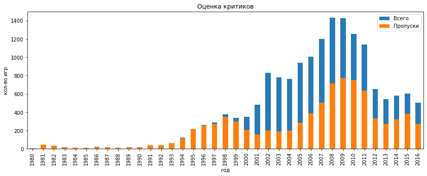

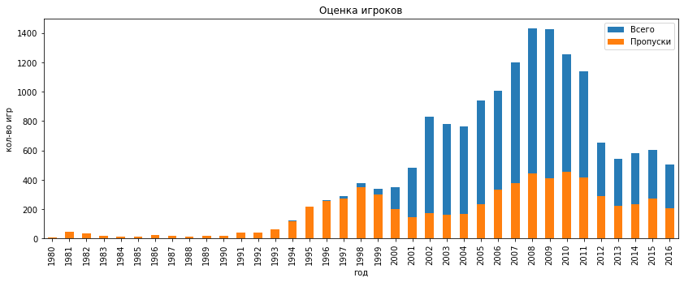

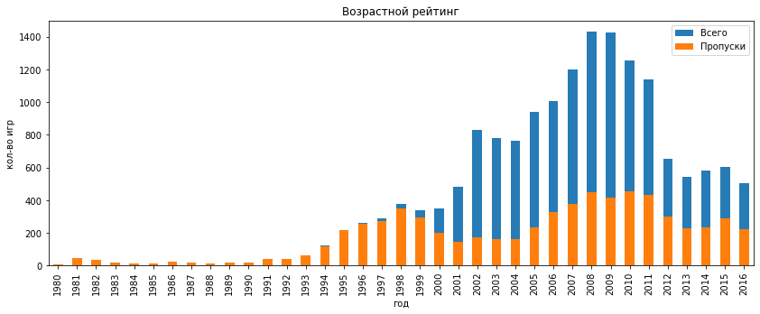

```python
list_na = ['critic_score','user_score','rating']
list_name_na = ['Оценка критиков','Оценка игроков','Возрастной рейтинг']


for i in range(len(list_na)):
    fig, ax = plt.subplots(figsize=(14,5))
    (
        df['year_of_release'].value_counts().sort_index()
        .plot(kind='bar', ax=ax, grid=True, color='#277bb6')
    )
    (
        df.loc[df[list_na[i]].isna()]['year_of_release'].value_counts().sort_index()
        .plot(kind='bar', ax=ax, color='#ff7f0e')
    )

    plt.title(list_name_na[i])
    ax.legend(['Всего', 'Пропуски'])
    plt.xlabel('год')
    plt.ylabel('кол-во игр');
```

Можно увидить как распределяются пропуски по годам. Весь столбец это сколько всего строк, желтая часть - это пропуски, соответсвенно синяя часть столбца на гистрограмме это данные без пропусков.

Больше всего пропусков в оценке критиков с 2007-2011 куда приходится пик всех данных по годам. Так же до 2001 года большинство данных не имеет оценки критиков. Крайние года с 2012 по 2016 пропуски имеют болше половины данных.

У оценки пользователей и рейтингу картина практически одинаковая по пропускам. Так же как у критиков до 2001 года большинство данных не данных по оценке пользователей и рейтингу. Крайние года с 2012 по 2016 пропуски примерно у половины данных.

Теперь посмотрим как распределяются пропуски по платформам:

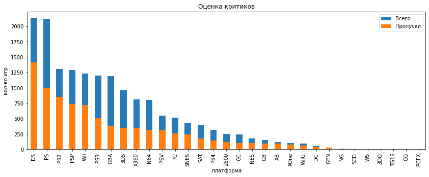

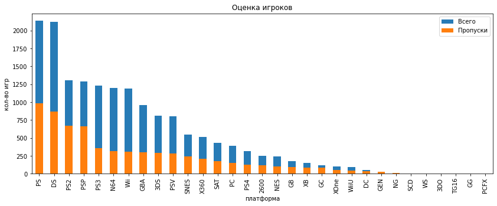

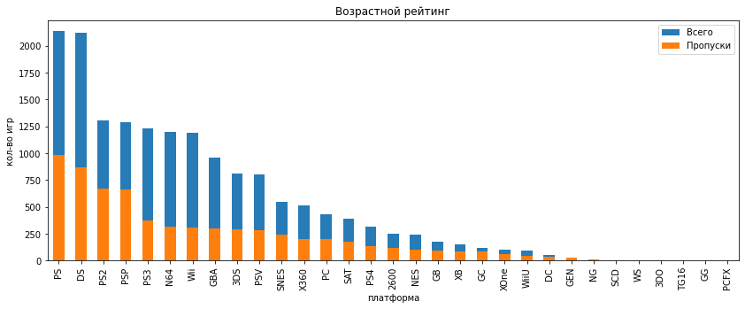

```python
for i in range(len(list_na)):
    fig, ax = plt.subplots(figsize=(14,5))
    (
        df['platform'].value_counts()
        .plot(kind='bar', ax=ax, grid=True, color='#277bb6')
    )
    (
        df.loc[df[list_na[i]].isna()]['platform'].value_counts()
        .plot(kind='bar', ax=ax, color='#ff7f0e')
    )

    plt.title(list_name_na[i])
    ax.legend(['Всего', 'Пропуски'])
    plt.xlabel('платформа')
    plt.ylabel('кол-во игр');
```

Хорошо, переходим дальше.

## Анализ данных

- Посмотрим сколько игр вышло на разных платформах и выведим гистрограмму:

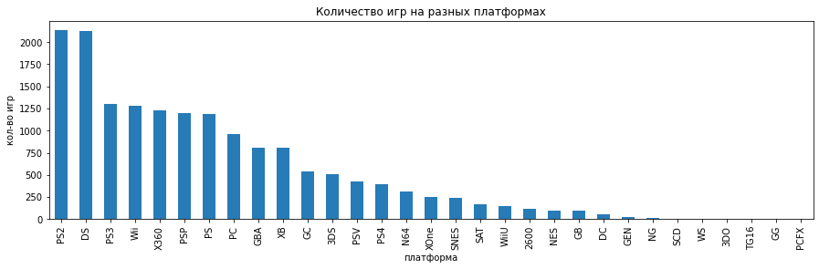

```python
df['platform'].value_counts().plot(kind='bar', color='#277bb6', figsize=(15,4));
plt.title('Количество игр на разных платформах')
plt.xlabel('платформа')
plt.ylabel('кол-во игр');
```

- Посмотрим сколько игр вышло по годам и также построим гистрограмму распределения:

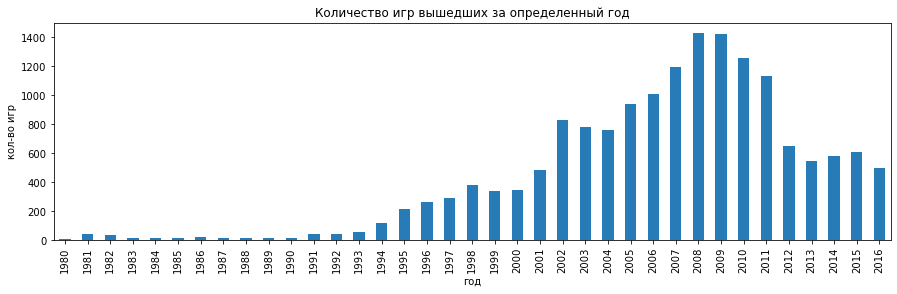

```python
df['year_of_release'].value_counts().sort_index().plot(kind='bar', color='#277bb6', figsize=(15,4))
plt.title('Количество игр вышедших за определенный год')
plt.xlabel('год')
plt.ylabel('кол-во игр');
```

- Платформы с наибольшим количеством игр это `Play Station 2`(2134) и `Nintendo DS`(2122)
- Пик выхода игр приходится на 2008-2009 годы.
- График по годам выхода является скошенным влево, для дополнительной наглядности выведем диаграмму размаха:

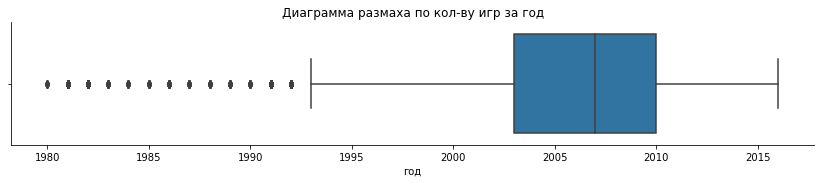

```python
g = sns.catplot(x='year_of_release', kind="box", data= df, orient='h')
g.fig.set_figwidth(12)
g.fig.set_figheight(2)
plt.title('Диаграмма размаха по кол-ву игр за год')
plt.xlabel('год');
```

Видим что большинство игр в базе выходило с 1993 по 2016.

Посмотрим, как менялись продажи по платформам.

Выберим топ 10 платформ с наибольшими суммарными продажами и построим распределение по годам.

```
          all_sales
platform
PS2         1247.28
X360         961.30
PS3          931.33
Wii          891.18
DS           802.79
PS           727.58
PS4          314.14
GBA          312.88
PSP          290.34
3DS          257.81
```

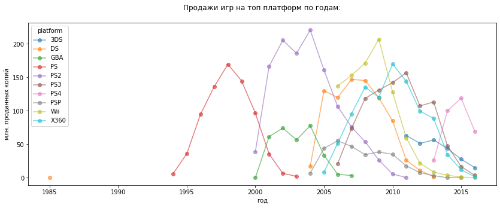

```python
# соберем топ платформ
top_sales = (
    df.pivot_table(index='platform', values='all_sales', aggfunc='sum')
    .sort_values('all_sales', ascending=False)
    .head(10)
)

# Выведем топ платформ
print(top_sales)

sales = top_sales.index

# Отсортируем все по списку платформ
group_platform_sales = df.query('platform in @sales')


(group_platform_sales
 .pivot_table(index='platform', columns='year_of_release', values='all_sales', aggfunc='sum')
 .T
 .plot(kind='line', figsize=(14,5),  style = 'o-', alpha=.6)
)
plt.title('Продажи игр на топ платформ по годам:'+ "\n")
plt.xlabel('год')
plt.ylabel('млн. проданных копий');
```

```python
group_platform_sales.pivot_table(index='platform', columns='year_of_release', values='all_sales', aggfunc='sum').T
```

| platform year_of_release | 3DS | DS | GBA | PS | PS2 | PS3 | PS4 | PSP | Wii | X360 |
| --- | --- | --- | --- | --- | --- | --- | --- | --- | --- | --- |
| 1985 | NaN | 0.02 | NaN | NaN | NaN | NaN | NaN | NaN | NaN | NaN |
| 1994 | NaN | NaN | NaN | 6.03 | NaN | NaN | NaN | NaN | NaN | NaN |
| 1995 | NaN | NaN | NaN | 35.96 | NaN | NaN | NaN | NaN | NaN | NaN |
| 1996 | NaN | NaN | NaN | 94.70 | NaN | NaN | NaN | NaN | NaN | NaN |
| 1997 | NaN | NaN | NaN | 136.17 | NaN | NaN | NaN | NaN | NaN | NaN |
| 1998 | NaN | NaN | NaN | 169.49 | NaN | NaN | NaN | NaN | NaN | NaN |
| 1999 | NaN | NaN | NaN | 144.53 | NaN | NaN | NaN | NaN | NaN | NaN |
| 2000 | NaN | NaN | 0.07 | 96.37 | 39.17 | NaN | NaN | NaN | NaN | NaN |
| 2001 | NaN | NaN | 61.53 | 35.59 | 166.43 | NaN | NaN | NaN | NaN | NaN |
| 2002 | NaN | NaN | 74.16 | 6.67 | 205.38 | NaN | NaN | NaN | NaN | NaN |
| 2003 | NaN | NaN | 56.67 | 2.07 | 185.93 | NaN | NaN | NaN | NaN | NaN |
| 2004 | NaN | 17.27 | 77.91 | NaN | 220.55 | NaN | NaN | 7.06 | NaN | NaN |
| 2005 | NaN | 130.14 | 33.86 | NaN | 160.98 | NaN | NaN | 43.84 | NaN | 8.25 |
| 2006 | NaN | 119.81 | 5.28 | NaN | 106.46 | 20.96 | NaN | 55.32 | 137.15 | 51.62 |
| 2007 | NaN | 146.94 | 3.40 | NaN | 75.99 | 73.19 | NaN | 46.93 | 152.77 | 95.42 |
| 2008 | NaN | 145.32 | NaN | NaN | 53.90 | 118.52 | NaN | 34.56 | 171.32 | 135.26 |
| 2009 | NaN | 119.54 | NaN | NaN | 26.40 | 130.93 | NaN | 38.58 | 206.97 | 120.29 |
| 2010 | NaN | 85.02 | NaN | NaN | 5.64 | 142.17 | NaN | 35.04 | 127.95 | 170.03 |
| 2011 | 63.20 | 26.18 | NaN | NaN | 0.45 | 156.78 | NaN | 17.82 | 59.65 | 143.89 |
| 2012 | 51.36 | 11.01 | NaN | NaN | NaN | 107.35 | NaN | 7.69 | 21.71 | 99.74 |
| 2013 | 56.57 | 1.54 | NaN | NaN | NaN | 113.25 | 25.99 | 3.14 | 8.59 | 88.58 |
| 2014 | 43.76 | NaN | NaN | NaN | NaN | 47.76 | 100.00 | 0.24 | 3.75 | 34.74 |
| 2015 | 27.78 | NaN | NaN | NaN | NaN | 16.82 | 118.90 | 0.12 | 1.14 | 11.96 |
| 2016 | 15.14 | NaN | NaN | NaN | NaN | 3.60 | 69.25 | NaN | 0.18 | 1.52 |

У платформы `DS` видно выброс в 1985 году, хотя платформа вышла в 2004, посмотрим подробнее на строки:

```python
df.loc[(df['year_of_release'] < 2004)&(df['platform'] == 'DS')]
```

|  | name | platform | year_of_release | genre | na_sales | eu_sales | jp_sales | other_sales | critic_score | user_score | rating | all_sales |
| --- | --- | --- | --- | --- | --- | --- | --- | --- | --- | --- | --- | --- |
| 15957 | Strongest Tokyo University Shogi DS | DS | 1985 | Action | 0.0 | 0.0 | 0.02 | 0.0 | NaN | NaN | NaN | 0.02 |

По названию игры выясняли что она вышла в 2010 поправим это в таблице:

```python
df.loc[15957,'year_of_release'] = 2010 #поправим год
group_platform_sales = df.query('platform in @sales') #обновим переменную
df.loc[15957]#посмотрим строку после замены
```

```
name               Strongest Tokyo University Shogi DS
platform                                            DS
year_of_release                                   2010
genre                                           Action
na_sales                                           0.0
eu_sales                                           0.0
jp_sales                                          0.02
other_sales                                        0.0
critic_score                                       NaN
user_score                                         NaN
rating                                             NaN
all_sales                                         0.02
Name: 15957, dtype: object
```

Для наглядности выведем диаграмму размаха по платформам:

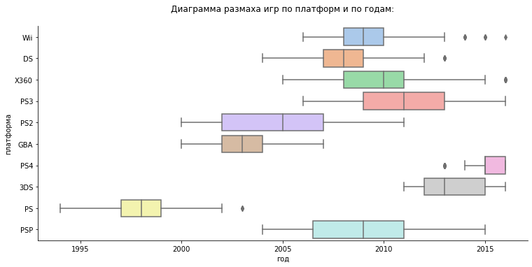

```python
p = sns.catplot(y='platform', x='year_of_release', kind="box", data = group_platform_sales, orient='h', palette = 'pastel')
p.fig.set_figwidth(12)
p.fig.set_figheight(5)
plt.title('Диаграмма размаха игр по платформ и по годам:'+ "\n")
plt.xlabel('год')
plt.ylabel('платформа');
```

```python
cc = group_platform_sales['year_of_release'].value_counts().sort_index().reset_index()
```

Визуально трудно определить жизненый цикл платформы.

Чтобы лучше отобразить сбросим к нулю все платформы, по первой вышедшей игре на платформе:

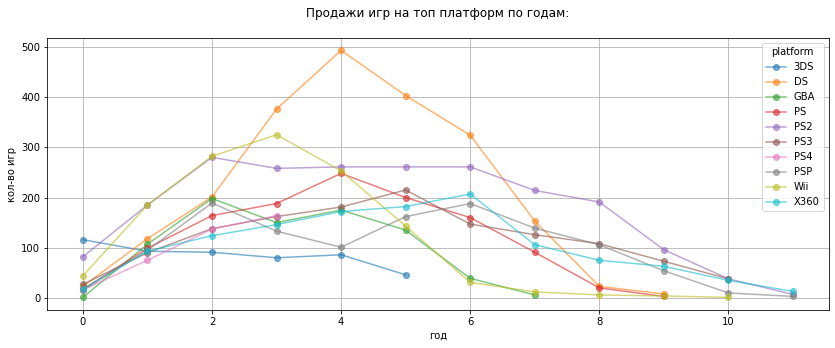

```python
top_platform_count = (
    group_platform_sales
    .pivot_table(index='platform', columns='year_of_release', values='all_sales', aggfunc='count')
    .T
    .reset_index(drop=True)
)

for col in top_platform_count.columns:
    top_platform_count[col] = top_platform_count[col].dropna().reset_index(drop=True)

(
    top_platform_count
    .plot(kind='line', figsize=(14,5),  style = 'o-', alpha=.6, grid=True)
)
plt.title('Продажи игр на топ платформ по годам:'+ "\n")
plt.xlabel('год')
plt.ylabel('кол-во игр');
```

```python
top_platform_count
```

| platform | 3DS | DS | GBA | PS | PS2 | PS3 | PS4 | PSP | Wii | X360 |
| --- | --- | --- | --- | --- | --- | --- | --- | --- | --- | --- |
| 0 | 116.0 | 23.0 | 1.0 | 17.0 | 82.0 | 27.0 | 16.0 | 15.0 | 44.0 | 18.0 |
| 1 | 93.0 | 118.0 | 107.0 | 99.0 | 185.0 | 90.0 | 75.0 | 95.0 | 185.0 | 93.0 |
| 2 | 91.0 | 201.0 | 198.0 | 164.0 | 280.0 | 138.0 | 137.0 | 189.0 | 282.0 | 124.0 |
| 3 | 80.0 | 376.0 | 150.0 | 188.0 | 258.0 | 162.0 | 164.0 | 133.0 | 325.0 | 146.0 |
| 4 | 86.0 | 493.0 | 175.0 | 248.0 | 261.0 | 181.0 | NaN | 101.0 | 253.0 | 172.0 |
| 5 | 46.0 | 403.0 | 135.0 | 200.0 | 261.0 | 215.0 | NaN | 162.0 | 143.0 | 182.0 |
| 6 | NaN | 324.0 | 39.0 | 160.0 | 261.0 | 147.0 | NaN | 188.0 | 31.0 | 207.0 |
| 7 | NaN | 153.0 | 6.0 | 91.0 | 214.0 | 126.0 | NaN | 139.0 | 12.0 | 106.0 |
| 8 | NaN | 23.0 | NaN | 20.0 | 191.0 | 108.0 | NaN | 106.0 | 6.0 | 75.0 |
| 9 | NaN | 8.0 | NaN | 3.0 | 96.0 | 73.0 | NaN | 54.0 | 4.0 | 63.0 |
| 10 | NaN | NaN | NaN | NaN | 38.0 | 38.0 | NaN | 10.0 | 1.0 | 35.0 |
| 11 | NaN | NaN | NaN | NaN | 7.0 | NaN | NaN | 3.0 | NaN | 13.0 |
| 12 | NaN | NaN | NaN | NaN | NaN | NaN | NaN | NaN | NaN | NaN |
| 13 | NaN | NaN | NaN | NaN | NaN | NaN | NaN | NaN | NaN | NaN |
| 14 | NaN | NaN | NaN | NaN | NaN | NaN | NaN | NaN | NaN | NaN |
| 15 | NaN | NaN | NaN | NaN | NaN | NaN | NaN | NaN | NaN | NaN |
| 16 | NaN | NaN | NaN | NaN | NaN | NaN | NaN | NaN | NaN | NaN |
| 17 | NaN | NaN | NaN | NaN | NaN | NaN | NaN | NaN | NaN | NaN |
| 18 | NaN | NaN | NaN | NaN | NaN | NaN | NaN | NaN | NaN | NaN |
| 19 | NaN | NaN | NaN | NaN | NaN | NaN | NaN | NaN | NaN | NaN |
| 20 | NaN | NaN | NaN | NaN | NaN | NaN | NaN | NaN | NaN | NaN |
| 21 | NaN | NaN | NaN | NaN | NaN | NaN | NaN | NaN | NaN | NaN |
| 22 | NaN | NaN | NaN | NaN | NaN | NaN | NaN | NaN | NaN | NaN |

С этим знанием для прогнозирования 2017 года возьмем данные начиная с 2013 так как это будет *актуальный срез* - так как предыдущие платформы уже будут сходить на нет, и мы выявим самые актуальные.

```python
(group_platform_sales
 .pivot_table(index='platform', columns='year_of_release', values='all_sales', aggfunc='count').nunique().median()
)
```

```
5.0
```

```python
crop_df = df.loc[df['year_of_release'] >= 2013].reset_index(drop=True)

crop_df.head()
```

|  | name | platform | year_of_release | genre | na_sales | eu_sales | jp_sales | other_sales | critic_score | user_score | rating | all_sales |
| --- | --- | --- | --- | --- | --- | --- | --- | --- | --- | --- | --- | --- |
| 0 | Grand Theft Auto V | PS3 | 2013 | Action | 7.02 | 9.09 | 0.98 | 3.96 | 97.0 | 8.2 | M | 21.05 |
| 1 | Grand Theft Auto V | X360 | 2013 | Action | 9.66 | 5.14 | 0.06 | 1.41 | 97.0 | 8.1 | M | 16.27 |
| 2 | Call of Duty: Black Ops 3 | PS4 | 2015 | Shooter | 6.03 | 5.86 | 0.36 | 2.38 | NaN | NaN | NaN | 14.63 |
| 3 | Pokemon X/Pokemon Y | 3DS | 2013 | Role-Playing | 5.28 | 4.19 | 4.35 | 0.78 | NaN | NaN | NaN | 14.60 |
| 4 | Grand Theft Auto V | PS4 | 2014 | Action | 3.96 | 6.31 | 0.38 | 1.97 | 97.0 | 8.3 | M | 12.62 |

Чтобы выполнять дальнейшие операции приведем тип данных у пользовательский оценок к десятичному числу, из за этого придется убрать значение `tbd` - которая обозначает что оценки еще нет она появится позже. Чтобы оставить эту группу присвоим пропуск.

Так как рейтинг критиков и пользователей измеряется разными значениями (100 и 10) приведем к общему знаменателю к 100 балам.

```python
crop_df.loc[crop_df['user_score'] == 'tbd','user_score'] = np.nan #оценка будет позже

crop_df['user_score'] = crop_df['user_score'].astype('float64') * 10

crop_df.info()
```

```
<class 'pandas.core.frame.DataFrame'>
RangeIndex: 2234 entries, 0 to 2233
Data columns (total 12 columns):
 #   Column           Non-Null Count  Dtype
---  ------           --------------  -----
 0   name             2234 non-null   object
 1   platform         2234 non-null   object
 2   year_of_release  2234 non-null   int32
 3   genre            2234 non-null   object
 4   na_sales         2234 non-null   float64
 5   eu_sales         2234 non-null   float64
 6   jp_sales         2234 non-null   float64
 7   other_sales      2234 non-null   float64
 8   critic_score     992 non-null    float64
 9   user_score       1193 non-null   float64
 10  rating           1257 non-null   object
 11  all_sales        2234 non-null   float64
dtypes: float64(7), int32(1), object(4)
memory usage: 200.8+ KB
```

Посмотрим распределение объемов продаж в зависимоти от платформы.

Так же выведем график количиства игр вышедших на этих платформах.

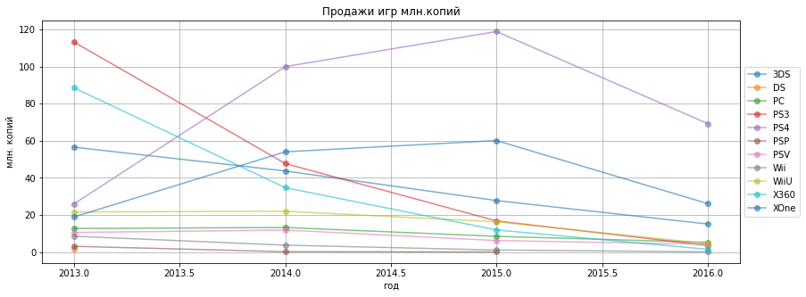

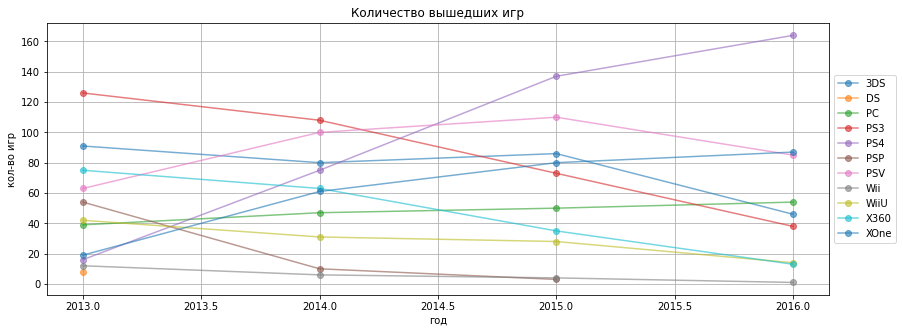

```python
(crop_df
 .pivot_table(index='platform', columns='year_of_release', values='all_sales', aggfunc='sum')
 .T
 .plot(kind='line', figsize=(14,5),  style = 'o-', alpha=.6, title='Продажи игр млн.копий', grid=True)
);
plt.xlabel('год')
plt.ylabel('млн. копий');
plt.legend(loc='center left', bbox_to_anchor=(1, 0.5));
(crop_df
 .pivot_table(index='platform', columns='year_of_release', values='name', aggfunc='count')
 .T
 .plot(kind='line', figsize=(14,5),  style = 'o-', alpha=.6, title='Количество вышедших игр', grid=True)
);
plt.xlabel('год')
plt.ylabel('кол-во игр');
plt.legend(loc='center left', bbox_to_anchor=(1, 0.5));#вынос легенды за пределы таблицы
```

Самая актуальная текущая платформа PS4, при уменьшении в 2016г объема проданных копиий относительно 2015г. с 118 млн.проданных копий игр до 70 млн. количество выпущенных игр увеличивается с момента выхода консоли (2013).

На втором месте XOne с 26 млн.проданных копий игр в 2016.

Самые снижающиеся платформы X360, PS3 и Wii они скатились с 170, 140 и 126 млн.проданных копий игр соответсвенно в 2010 до менее 6 млн.копий на всех этих трех платформах вместе взятых.

Можно заметить общее снижение в 2016г. возможно это связанно с информацией о том что данные за 2016 год могут быть не полными. Соответсвенно показатели в 2016 году могут быть выше чем за 2015 год.

Построим диаграмму размаха по глобальным продажам игр в разбивке по платформам.

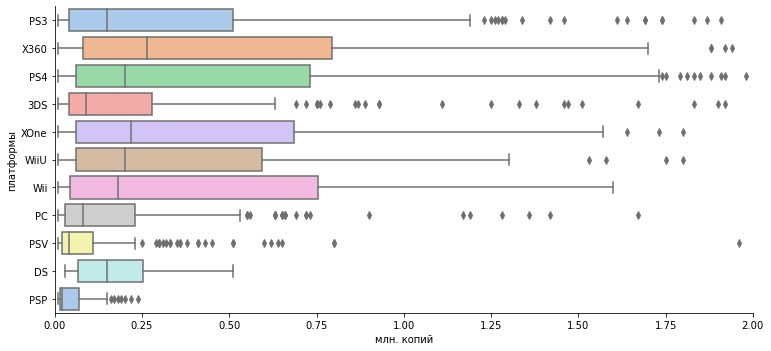

```python
crop_box = sns.catplot(y='platform', x='all_sales', kind="box", data = crop_df, orient='h', palette = 'pastel' )
crop_box.fig.set_figwidth(12)
crop_box.fig.set_figheight(5)
plt.xlim(0, 2)
plt.xlabel('млн. копий')
plt.ylabel('платформы');
```

Построим диаграмму рассеяния и посчитайем корреляцию между оценкой критиков и продажами.

вначале оценку критиков и объемов продаж:

```
Корреляция оценки критиков и объемов продаж: 0.31322157248964344
```

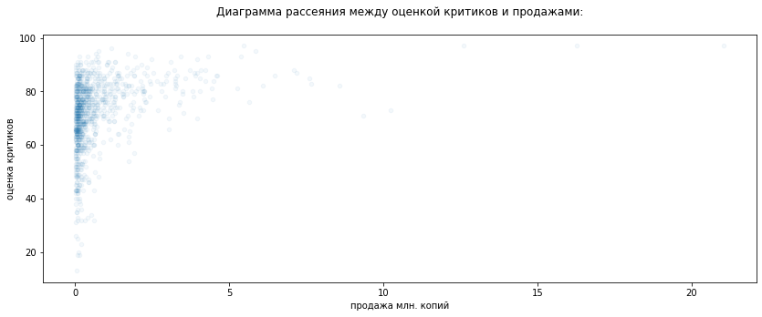

```python
crop_df.plot(x='all_sales', y='critic_score', kind='scatter', alpha=0.05, figsize=(14,5))
plt.title('Диаграмма рассеяния между оценкой критиков и продажами:'+ "\n")
plt.xlabel('продажа млн. копий')
plt.ylabel('оценка критиков');
print('Корреляция оценки критиков и объемов продаж:' , crop_df['critic_score'].corr(crop_df['all_sales']))
```

Посмотрим корреляцию оценки игроков и объемом продаж:

```
Корреляция оценки критиков и объемов продаж: -0.0028452436754022054
```

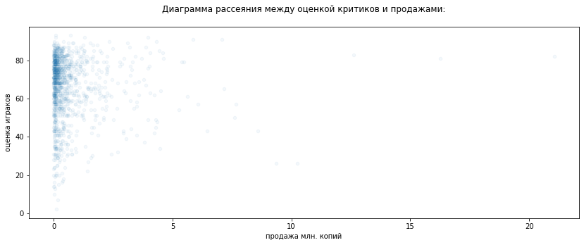

```python
crop_df.plot(x='all_sales', y='user_score', kind='scatter', alpha=0.05, figsize=(14,5))
plt.title('Диаграмма рассеяния между оценкой критиков и продажами:'+ "\n")
plt.xlabel('продажа млн. копий')
plt.ylabel('оценка играков');
print('Корреляция оценки критиков и объемов продаж:' ,crop_df['user_score'].corr(crop_df['all_sales']))
```

Посмотрим корреляцию по платформам, выведем графики рассеивания:

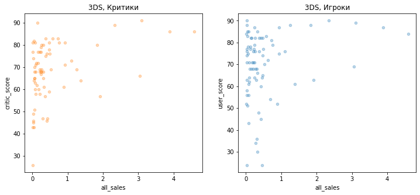

[figure not shown]

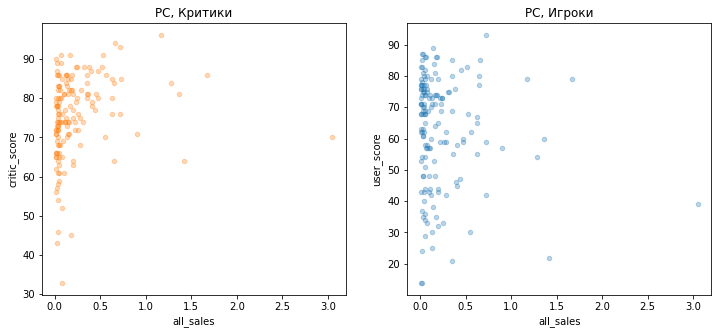

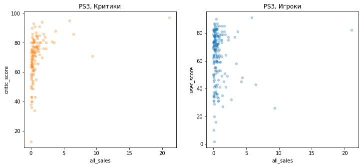

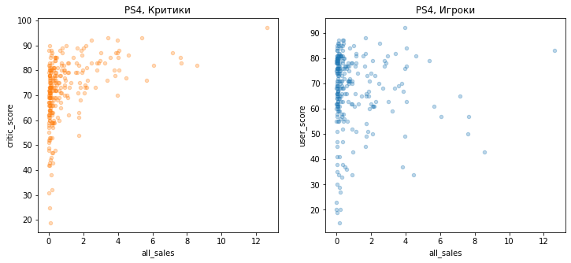

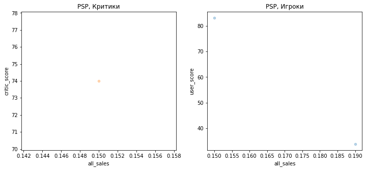

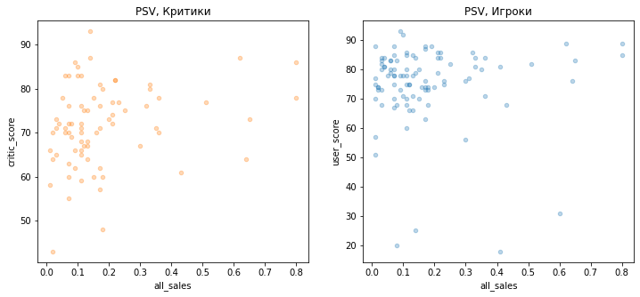

[figure not shown]

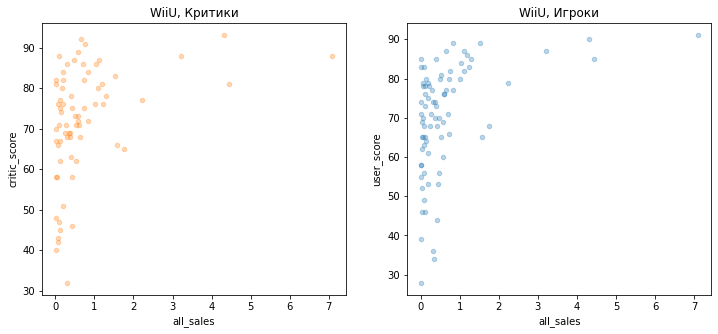

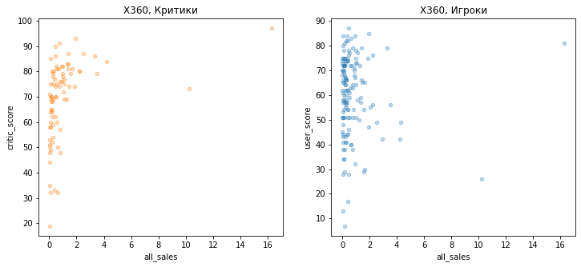

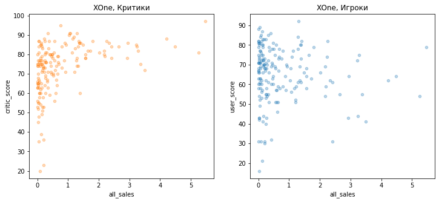

```python
platform_list_crop = crop_df['platform'].value_counts().index

group_platform_crop = crop_df.query('platform in @platform_list_crop')

corr_list = [[],[],[]]

for name, group_data in group_platform_crop.groupby('platform'):
    fig, ax = plt.subplots(ncols=2, figsize=(12,5))# будем выводить две колонки рядом для визуального удобства.
    corr_list[0].append(name) # добавим имя платформы в список.
    # выводим наши графики:

    group_data.plot(
        x='all_sales', y='critic_score', kind='scatter', alpha=0.3, title=(name+', Критики'), color='#ff7f0e', ax=ax[0]
    )

    group_data.plot(
        x='all_sales', y='user_score', kind='scatter', alpha=0.3, title=(name+', Игроки'), ax=ax[1]
    )

    # посчитаем корреляцию и добавим ее в соответсвующуй список:
    corr_list[1].append(group_data['critic_score'].corr(group_data['all_sales']))
    corr_list[2].append(group_data['user_score'].corr(group_data['all_sales']))


corr_tab = pd.DataFrame(data=corr_list, index=['platform','critic_score','user_score']).T.pivot_table(columns='platform')
corr_tab = corr_tab.fillna(0)
corr_tab = round(corr_tab, 3)
```

```python
print('Корреляция оценки критиков или игроков и объемов продаж'+ "\n")
corr_tab
```

```
Корреляция оценки критиков или игроков и объемов продаж
```

| platform | 3DS | PC | PS3 | PS4 | PSP | PSV | Wii | WiiU | X360 | XOne |
| --- | --- | --- | --- | --- | --- | --- | --- | --- | --- | --- |
| critic_score | 0.357 | 0.197 | 0.334 | 0.407 | 0.0 | 0.255 | 0.000 | 0.376 | 0.350 | 0.417 |
| user_score | 0.242 | -0.091 | 0.002 | -0.032 | -1.0 | 0.001 | 0.683 | 0.419 | -0.012 | -0.069 |